# First Filtering Pass for SNP Calling

So I ran a quick and dirty assembly from all the separate parts and then merged individual VCF files to get a first view of how things are sorting out.

Published

February 22, 2023

```r
library( tidyverse)
```

First, I took the new data and made in index and then verged it with the previous VCF files (from [here](https://dyerlab.org/posts/2023-02-14-variant-filtering/)). I set up filtering to have a minimum `QUAL` score of 20, no insertion/deletions, minimum allele count of 5 indiviudals posessing the alternative allele state to have the loci be considered, and only loci with 2 alleles present.

[output not shown]

```
vcftools --vcf FirstRun.vcf --remove-indels --minQ 20 --min-meanDP 20 --max-meanDP 3700 --mac 5 --min-alleles 2 --max-alleles 2  --freq --out first_run
```

This gives me a distribution of loci whose allele frequencies are:

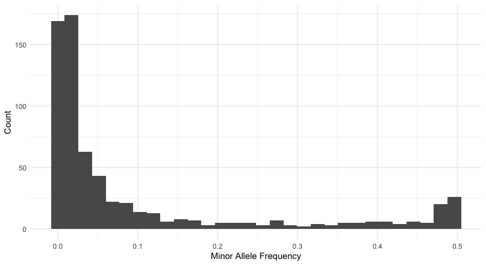

which leaves me with a reasonable number of loci to work with. At present, there are $663$ loci in the data set and if I were to filter at $p>=0.05$ that would still leave me with 234 to work with. Now let’s convert these into genotypes and start looking at missing data.